# Les Stars Canins de Twitter

Le compte twitter, devenu livre de par sa popularité, [@WeRateDogs](https://twitter.com/dog_rates?ref_src=twsrc%5Egoogle%7Ctwcamp%5Eserp%7Ctwgr%5Eauthor) livre ses archives. L'analyse de ces derniers s'avère pour le moins particulière, compte tenu du système de notation spécial.

## Des chiens gagnent le coeur des internautes plus que d'autres

[@WeRateDogs](https://twitter.com/dog_rates?ref_src=twsrc%5Egoogle%7Ctwcamp%5Eserp%7Ctwgr%5Eauthor) a connu du succès pas seulement grâce aux commentaires hilarants de son auteur mais surtout les chiens eux-mêmes qui séduisent les passagers. Certains d'entre eux génèrent d'ailleurs une vague de retweets, en plus d'avoir eu de bonnes notes.

Toutefois, loin de blasphémer contre le sacré "They're good dogs, Brent", on peut se demander :

### Quelles sont les 10 chiens les plus appréciés ?

Pour les amateurs de chiens, ou encore ceux qui envisagent de l'être, voici la liste des noms qui ont suscité l'amour des internautes --qui sait, vous y trouverez peut-être le nom de votre chien du futur :

- Sam
- Stephan
- Duddles
- Bo
- Jamesy
- Zoey
- Buddy
- Lilly
- Canela
- Aja

En en prenant les 5 premiers, on peut voir les réactions que chacun a suscité, en termes de nombre de favoris et nombre de retweets, sur le graphe en dessous :

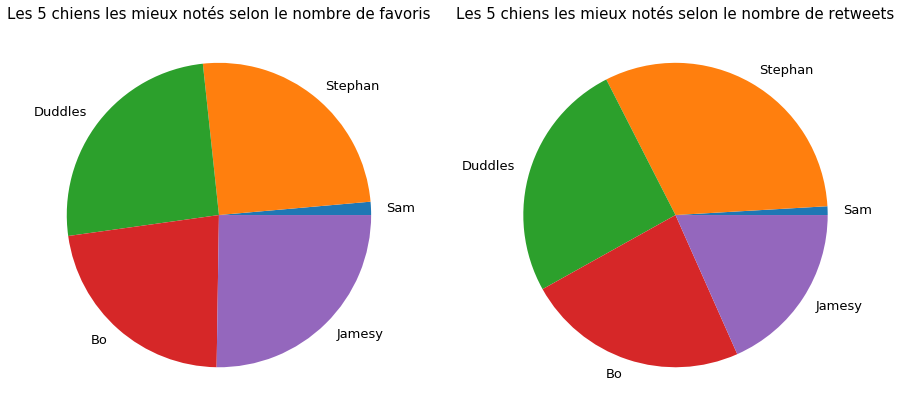

Il serait intéressant de savoir également que certaines races ont séduit plus que d'autre, à savoir :

- le chien esquimau,
- labrador retriever,
- chihuahua,
- golden retriever,
- cocker,
- caniche royal,
- terrier des lacs,
- bulldog français,
- Springer anglais.

Ce qui est étonnant cependant suite à cette anaylse est que, contrairement aux attentes, ce sont les puppos qui sont plus apprécié que les pupper. D'ailleurs, les pupper sont le moins appréciés !